# Smart KeyBoard-Data Exploration

trelo

## Abstract

The objective is to analyze three large corpus of text documents to discover the structure in the data and how words are put together.

The **blogs** and **news** datasets found are similar comapred to the **twitter** dataset. This could be due to the 140 character limit of Twitter messages.

## Introduction

In this report we explore at three datasets of US English text, a set of internet blogs posts, a set of internet news articles, and a set of twitter messages.

The reports lists following forms of information:

1. Files Information  
   1.1. File Size  
   1.2 Number of lines, Number of non-empty lines
2. File details  
   2.1 Number of words  
   2.2 Distribution of words (quantiles and plot)  
   2.3 Number of characters  
   2.4 Number of non-white characters

In the following section we will describe the data collection process, the section after that gives the results of the data exploration, we finally present conclusion for the analysis.

For our analysis we use the R computing environment R, as well as the libraries stringi stringi and ggplot2 ggplot2.

This report is compiled using rmarkdown and knitr. Finally, the milestone report is created in RStudio IDE RStudio.

## Data

The data is presented in compressed archive format, downloadable from [here](https://d396qusza40orc.cloudfront.net/dsscapstone/dataset/Coursera-SwiftKey.zip).

```r
# Download data
dest_file <- "Coursera-SwiftKey.zip"
source_file <- "http://d396qusza40orc.cloudfront.net/dsscapstone/dataset/Coursera-SwiftKey.zip"

# execute the download
download.file(source_file, dest_file)

# extract the files from the zip file
unzip(dest_file)
```

Unzip and list files

```r
# Ensure files are unzipped
unzip(dest_file, list = TRUE )

# Inspect data
list.files("final")
list.files("final/en_US")
```

The **blogs** and **twitter** datasets are in plain-text files, whereas the **news** dataset is binary format.

Import files

```r
# Import blogs and twitter datasets in text mode
blogsData <- readLines("final/en_US/en_US.blogs.txt", encoding="UTF-8")
twitterData <- readLines("final/en_US/en_US.twitter.txt", encoding="UTF-8")

# Import the news dataset in binary mode
con <- file("final/en_US/en_US.news.txt", open="rb")
newsData <- readLines(con, encoding="UTF-8")
close(con)
rm(con)
```

## Exploratory Analysis

Analysis of the file size and no. of lines.

```r
# file size (in MegaBytes/MB)
file.info("final/en_US/en_US.blogs.txt")$size   / 1024^2
```

```
## [1] 200.4242
```

```r
file.info("final/en_US/en_US.news.txt")$size    / 1024^2
```

```
## [1] 196.2775
```

```r
file.info("final/en_US/en_US.twitter.txt")$size / 1024^2
```

```
## [1] 159.3641
```

```r
#Sample data - work with 5% data
set.seed(4321)
l <- length(twitterData)
twitter_sample<-twitterData[sample.int(l,round(.05*l))]
l <- length(newsData)
news_sample<-newsData[sample.int(l,round(.05*l))]
l <- length(blogsData)
blogs_sample<-blogsData[sample.int(l,round(.05*l))]
```

Load required libraries for analysis

```r
# library for character string analysis
library(stringi)
# library for plotting
library(ggplot2)
library(grid)
library(gridExtra)
```

Analyze lines and characters

```r
stri_stats_general(blogsData)
```

```
##       Lines LinesNEmpty       Chars CharsNWhite
##      899288      899288   206824382   170389539
```

```r
stri_stats_general(newsData)
```

```
##       Lines LinesNEmpty       Chars CharsNWhite
##     1010242     1010242   203223154   169860866
```

```r
stri_stats_general(twitterData)
```

```
##       Lines LinesNEmpty       Chars CharsNWhite
##     2360148     2360148   162096031   134082634
```

Next we count the words per line. The below section summarises the distibution of these counts per dataset, using summary statistics and a distibution plot.

Analyze **Blogs** corpus.

```r
blogs_words <- stri_count_words(blogsData)
blogs_sample_words <- stri_count_words(blogs_sample)
summary(blogs_words)
```

```
##    Min. 1st Qu.  Median    Mean 3rd Qu.    Max.
##    0.00    9.00   28.00   41.75   60.00 6726.00
```

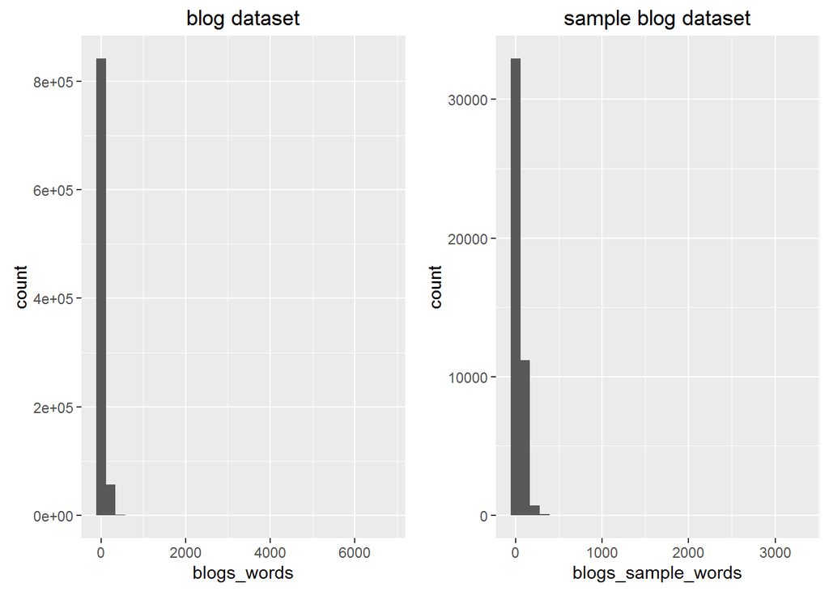

```r
b1 = qplot(blogs_words, main = "blog dataset")
b2 = qplot(blogs_sample_words, main = "sample blog dataset")
grid.arrange(b1, b2, ncol = 2)
```

Analyze **News** corpus

```r
news_words <- stri_count_words(newsData)
news_sample_words <- stri_count_words(news_sample)
summary(news_words)
```

```
##    Min. 1st Qu.  Median    Mean 3rd Qu.    Max.
##    1.00   19.00   32.00   34.41   46.00 1796.00
```

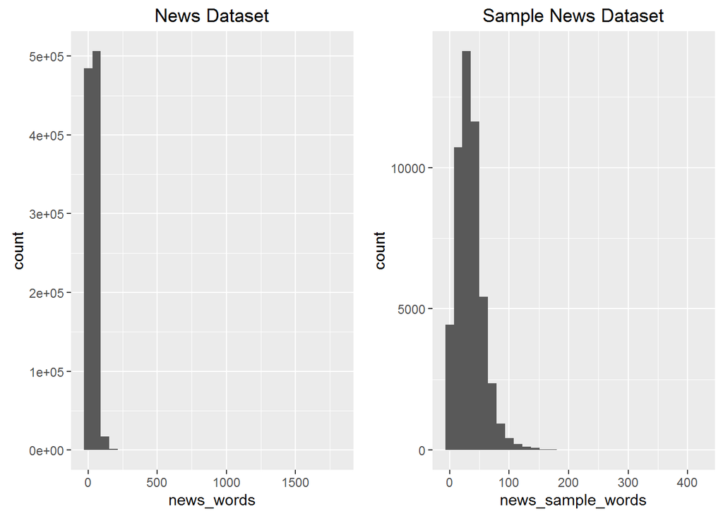

```r
n1 = qplot(news_words, main="News Dataset")
n2 = qplot(news_sample_words, main="Sample News Dataset")
grid.arrange(n1, n2, ncol = 2)
```

Analyse **Twitter** corpus.

```r
twitter_words <- stri_count_words(twitterData)
twitter_sample_words <- stri_count_words(twitter_sample)
summary(twitter_words)
```

```
##    Min. 1st Qu.  Median    Mean 3rd Qu.    Max.
##    1.00    7.00   12.00   12.75   18.00   47.00
```

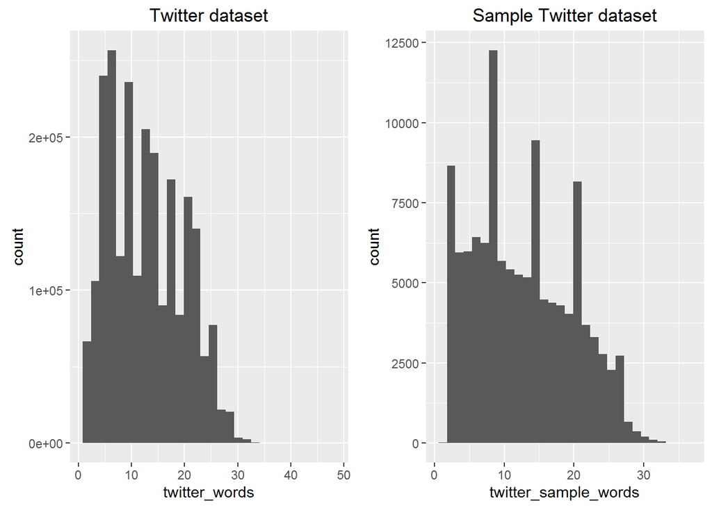

```r
t1 = qplot(twitter_words, main="Twitter dataset")
t2 = qplot(twitter_sample_words, main="Sample Twitter dataset")
grid.arrange(t1, t2, ncol = 2)
```

## Conclusions

We find that the **blogs** and **news** corpus consist of about 1 million items each, and the **twitter** corpus consist of over 2 million items. Twitter messages have a character limit of 140 (with exceptions for links), this explains why there are some many more items for a corpus of about the same size.

Finally we find that the frequency distributions of the **blogs** and **news** datasets are similar. The frequency distribution of the **twitter** dataset is again different, as a result of the character limit.

## References

1.Text mining infrastucture in R

2.[CRAN Task View: Natural Language Processing](http://cran.r-project.org/web/views/NaturalLanguageProcessing.html)